# Funciones en R

Esteban Arroyo

25-11-2025

Por lo general, una función es un bloque de código que puede ser reutilizable para realizar acciones u operaciones específicas y puede ser llamado en cualquier momento o parte del programa para ejecutar ese código.

Una función tiene la siguiente estructura: un nombre, argumentos y un cuerpo u operaciones o acciones a realizar.

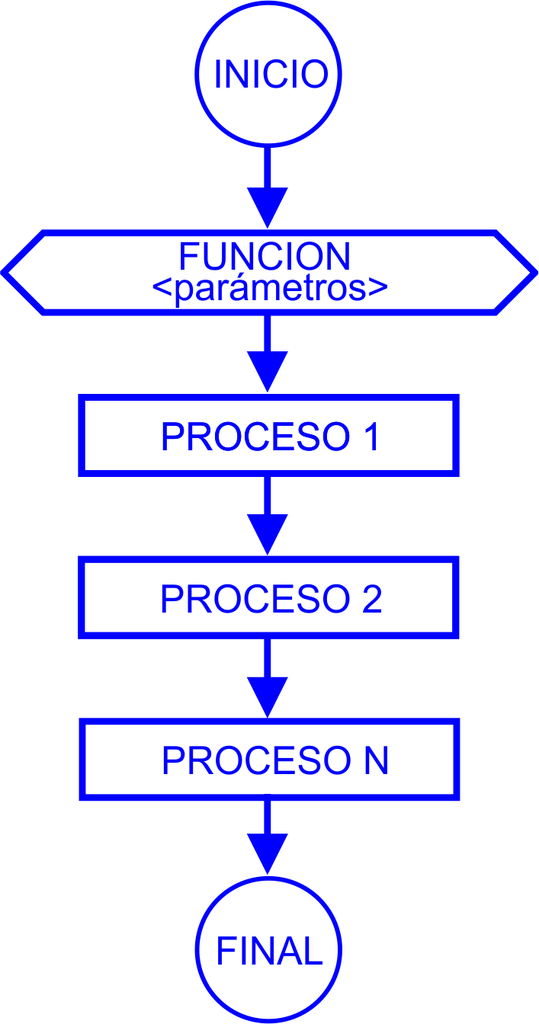

```r
nombre <- function(argumentos){
  operaciones, acciones, etc
}
```

- El nombre es importante porque nos permite llamar y ejecutar esa función
- Para que “r” sepa que estamos creando o definiendo una función usamos la palabra reservada “**function**” seguida de paréntesis “()” y llaves “{}”.
- El argumento, son las variables u objetos que necesita la función para realizar las operaciones o acciones y van entre los paréntesis “()”.
- El cuerpo o contenido van entre las llaves “{}”, y posee todas operaciones y/o acciones que se deben ejecutar cuando la función es llamada.

**Primera función**

Crearemos una función donde pediremos como argumento el nombre del usuario y la función imprimirá por consola un saludo junto con el nombre:

```r
saludo <- function(nombre){            # Definimos a la función con el nombre de “saludo”
  print(paste("Buenos días,", nombre)) #Como argumento creamos el objeto “nombre”
}                                      # El objeto nombre es tomado en el código print() para generar el saludo e imprimirlo por consola
```

Llamamos la función saludo() y dentro del paréntesis agregamos el nombre del usuario entre “” porque es un “string” o cadena de texto

```r
saludo("Esteban")
```

```
[1] "Buenos días, Esteban"
```

Observamos que el resultado se imprimió correctamente por consola.

**Funciones matemáticas**

Podemos hacer otra función donde realice algunas operaciones matemáticas, como la suma:

```r
suma <- function(x,y){                 #Esta función pide dos argumentos que llamamos "x" y "y"
  print(paste("La suma de",x, "y", y, "es:", x+y))    #Aquí hacemos la suma
}
```

Llamamos a la función “suma” y como argumento, usamos los valores 5 y 3

```r
suma(5,3)
```

```
[1] "La suma de 5 y 3 es: 8"
```

…y vemos que el resultado se imprime correctamente en la consola.

**Buenas practicas**

Un elemento importante, pero a veces omitido, es el uso del “**return()**” como instrucción final que evidencia el resultado que la función, es decir, indica que finaliza la ejecución de una función y devuelve explícitamente un valor. El uso “**return**” mejora la legibilidad, la claridad y ayuda a seguir prácticas de programación estándar, especialmente en funciones complejas o en entornos colaborativos donde la legibilidad es crucial. Entonces, mejorando la función de suma, no queda:

```r
sumados <- function(x,y){
  resultado <- x+y
  return(paste("La suma de", x, "+", y, "es:", resultado))
}

sumados(5,3)
```

```
[1] "La suma de 5 + 3 es: 8"
```

Ambas funciones suma() y sumado(), dan el mismo resultado, pero la última tiene mejor legibilidad, finaliza apropiadamente la ejecución, permite controlar el flujo, ya que es útil para manejar diferentes condiciones o casos y facilita la depuración, ya que al tener un único **return**, se puede rastrear y revisar posibles errores.

**Usando funciones con estructuras de control**

Muchas veces es necesario incluir estructuras de control dentro de una función, esto permite optimizar código y controlar el flujo de las acciones. Por ejemplo, en el caso del switch, funciona muy bien dentro de una función: continuamos con los ejemplos de operaciones matemáticas

```r
operacion <- function(opcion, x, y){
  switch (
    opcion,
    "s" = paste("Suma: ", x + y),
    "r" = paste("Resta: ", x - y),
    "m" = paste("Multiplicación: ", x * y),
    "d" = paste("División: ", x / y),
    "Opción no definida")
}
```

Llamando a la función y le indicamos que queremos una multiplicación de los números 3 y 4

```r
operacion("m", 3,4)
```

```
[1] "Multiplicación:  12"
```

…y vemos que el resultado se imprime correctamente en la consola.

**Nota**: cuando se usa el switch, no es necesario usar el “**return**”, que cada alternativa, arroja un return automático de acuerdo a la opción establecida.

**Otro ejemplo un poco más complejo:**

Se pide una función, que dado un valor ingresado por el usuario (como argumento en la función), genere números aleatorios entre cero y uno hasta que la suma de los números generados exceda por primera vez el valor ingresado por el usuario. La función debe entregar un vector con los números aleatorios, la suma y la cantidad de números aleatorios. Si el usuario no ingresa el valor, se debe asumir igual a 1.

```r
num.ale <- function(numero=1){       #Aqui definimos que el argumento numero sea igual 1
  vector <- NULL                     # Definimos un vector vacío, que despues se debe llenar
  while (sum(vector)<numero) {       #Usamos el while para controlar que la suma debe ser menor a número
      vector <- append(vector, runif(1))   #Aquí vamos agregando un numero aleatorio en cada ciclo
    }
  resultado <- list(vector, sum(vector), length(vector))  #guadamos todos los resultados en una lista
  return(resultado)                                       #retornamos ese resultado
}
```

Si usamos como argumento el número 2, el resultado será:

```r
num.ale(2)
```

```
[[1]]
[1] 0.0136709 0.6146475 0.7434386 0.2181038 0.6701324

[[2]]
[1] 2.259993

[[3]]
[1] 5
```

Pero si no colocamos nada, la función trabaja igual pero asumiendo el valor 1

```r
num.ale()
```

```
[[1]]
[1] 0.1627840 0.1773026 0.7072341

[[2]]
[1] 1.047321

[[3]]
[1] 3
```

**Otro ejemplo**

Construya una función que reciba dos números y que entregue el punto medio de estos números. El resultado debe ser un mensaje por pantalla.

```r
punto.medio <- function(a,b){
  media <- (a+b)/2
  return(paste("El punto medio de los valores", a, "y", b, "es:", media))
}

punto.medio(5,4)
```

```
[1] "El punto medio de los valores 5 y 4 es: 4.5"
```